# Business Formation Statistics Descriptives

Author

Inder Majumdar

Published

February 2, 2026

# Exploring the Business Formation Statistics Data

US Census Business Formation Statistics are found here: https://www.census.gov/econ/bfs/data.html

Before editing the figures, I’d like to get a sense of how Business Formation has changed in Wisconsin compared to other states (and inform intuition on how this will impact our Pitchbook/CORI outcomes of interest).

## How does Wisconsin Compare to other states w.r.t Business Applications (2005 to present)?

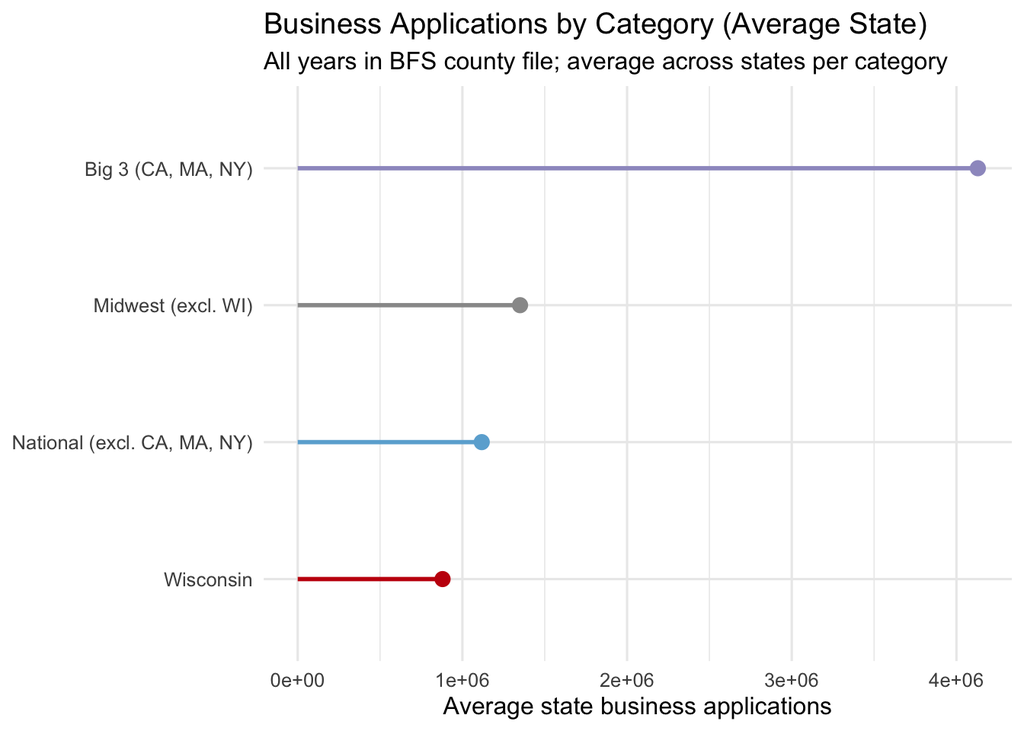

There are some obvious population effects at play here. Let’s zoom in on rural counties with the same average-state framing:

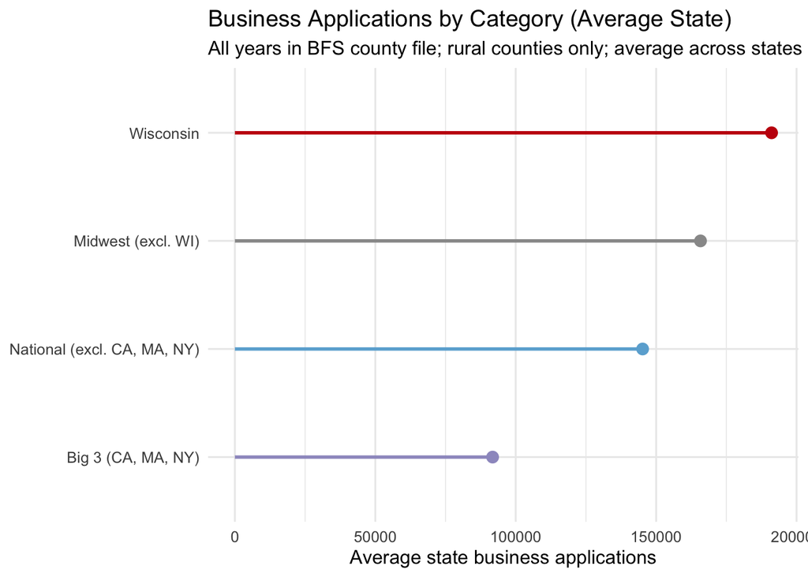

This pattern is striking. When I select only rural counties (RUCC codes > 3), Wisconsin leads compared to the “average” other state across categories. One way to interpret this is that while other metro areas are a hub for business formation, Wisconsin’s rural counties outperform the rural areas of other categories in expectation (I’ll need to refine this wording a bit…).

Descriptive patterns suggest that these patterns might be driven by adjacency effects. Look what happens when I select only on rural counties that are not adjacent to a metro area using RUCC definitions:

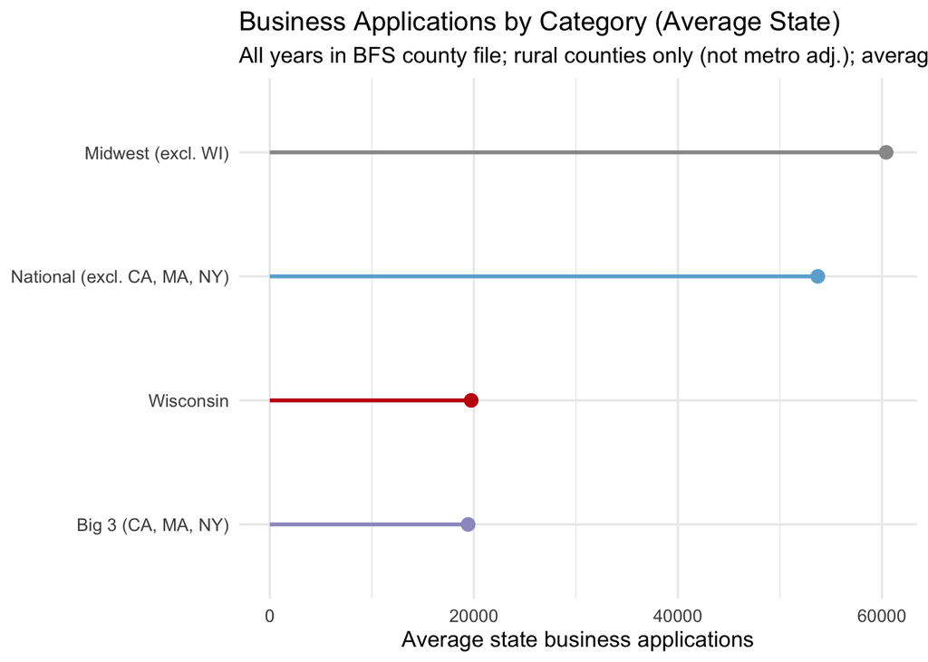

## Business Formation Over Time

The above graphs provide some intuition in the aggregate, but I’d like to see trends over time. Is the pattern we’re seeing in the aggregate driven by a recent trend upwards? Or have Wisconsin’s rural counties persistently outperformed relative to our benchmarks?

Below is a time series of yearly business formation data. I normalized the Y axis so the first value is an intercept, so we can view the time series as relative to 2005 values.

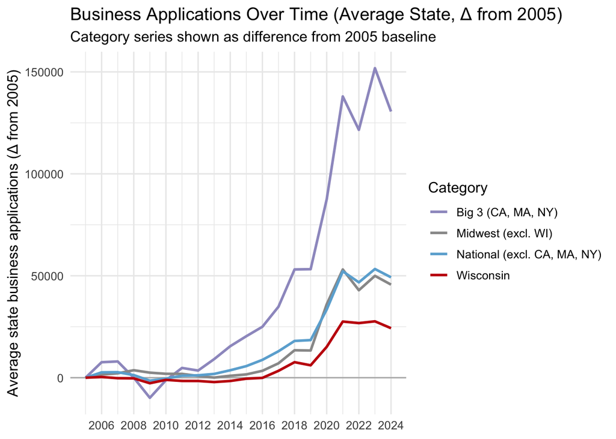

Repeating the same exercise for rural counties only, we see that Wisconsin saw a sharper contraction then what was typical in other regions of the county during the Great Financial Crisis.

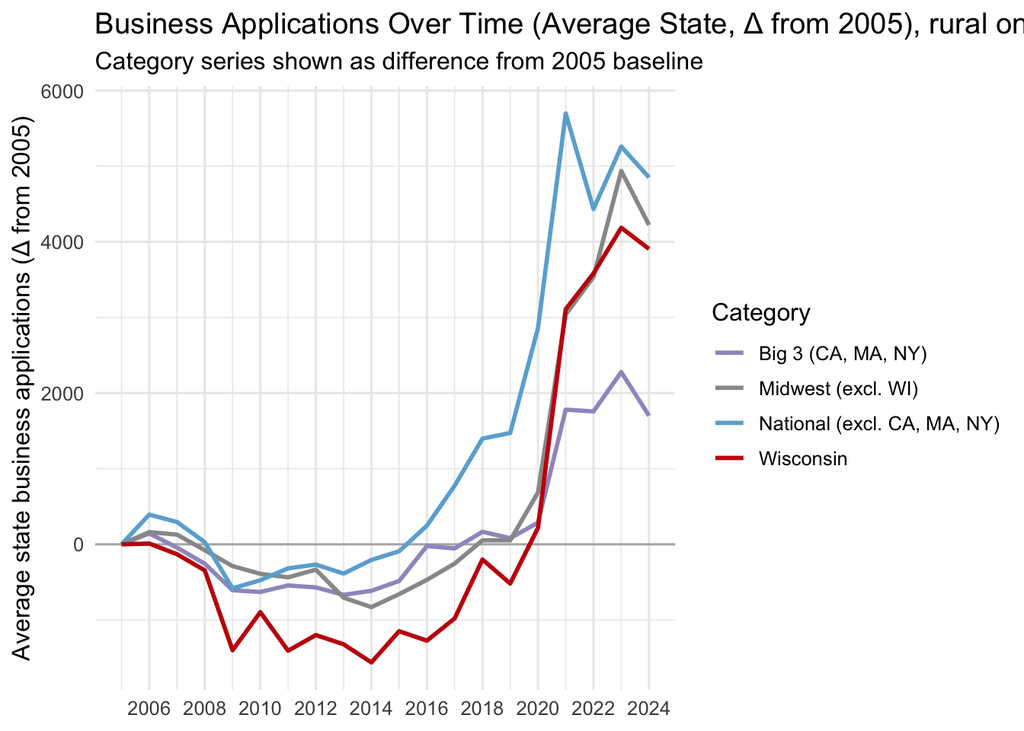

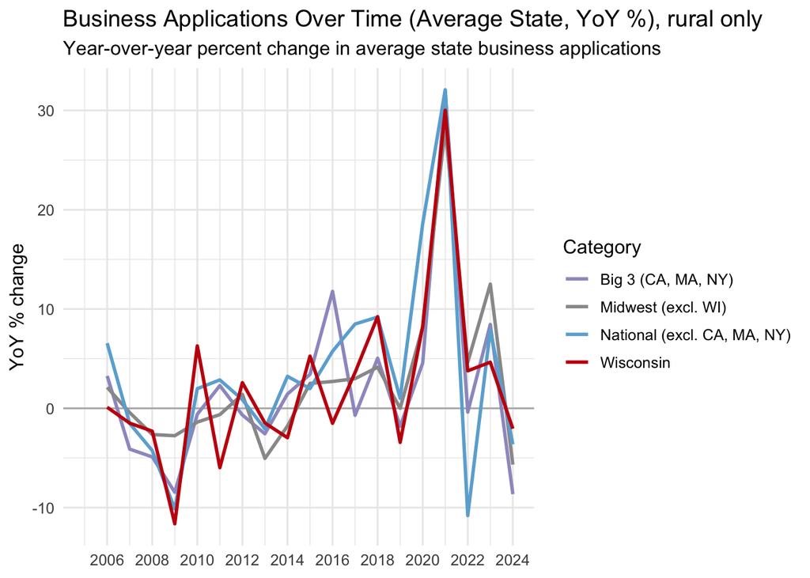

For completness, I’m including a county map characterizing percent change between 2005 and 2024, though I find the map less informative than the above graphs.

## Wisconsin county map: % change (2005 → 2024)

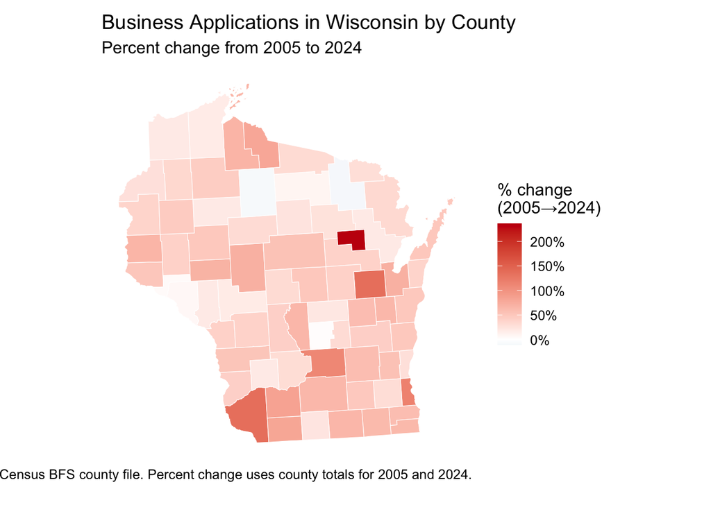